# New York Audit Algorithm Analysis

Jacob Spertus and Amanda Glazer

Initialized: 10/15/2019; Updated: 11/6/2019

```r
library(tidyverse)
library(Matrix)
source("audit_functions.R")
```

This notebook analyzes the current law in New York through simulations based on historic election returns at the machine level.

The original law can be found here. *Note: part h of the law indicates that county election boards can always proceed to recount at their discretion*

A summary of the law can be found at http://www.ncsl.org/research/elections-and-campaigns/post-election-audits635926066.aspx

# NY’s auditing algorithm

Summarizing the above into an algorithm, the audits proceed as follows:

1. For each county, select uniformly at random no less than 3% of each type of voting machine or system used
   1. Manually tabulate ballots from the VVPAT from selected machines
   2. On selected machines, compare manual tabulations to machine tabulations, and report any discrepancies
      1. If any (>= 1) discrepancies are found on a machine, recount all ballots from that machine.
   3. If any of the following apply expand the audit (proceed to 2), else end audit:
      1. any one or more discrepancies between the confirming manual counts and the original machine or system electronic counts, which taken together, would alter the vote share of any candidate, question or proposal by 0.1 percent or more of the hand counted votes for respective contests, questions, or proposals in the entire sample
      2. discrepancies of any amount are detected between the confirming manual count and the original machine or system electronic count from at least 10 percent of the machines or systems initially audited then the board or bipartisan team appointed by such board shall manually count the votes recorded on all the voter verifiable paper audit trail records from no less than an additional five percent of each type of the same type of voting machine or system which contains any such discrepancy or discrepancies
2. Sample 5% of machines uniformly at random and repeat 1b/c, considering the additional 5% sample as well as the original 3% sample (expanded to be 8% of all machines).
3. If 2 indicates expansion is warranted per 1c, sample 12% of machines uniformly at random (to expand to 20% of all machines) and repeat 1b/c
4. If 3 indicates expansion is warranted proceed to full hand recount

# A brief critique of the algorithm

In the worst case scenario, if discrepancies in a county are concentrated on one machine within one system, then this auditing procedure has only a 3% chance of catching the discrepancy. The more machines that have a discrepancy between true and reported outcomes, the more likely it is that this audit catches the discrepancy. However, if discrepancies are concentrated around a few machines then it is very unlikely that this audit will catch them. The figure below was generated by assuming that errors are concentrated on a small number of machines (the x-axis), that there are 1000 machines total in the county, and that if the audit happens to sample the machine then it will detect an error. We see that, even if it suffices to catch only one machine with bad results, it is fairly unlikely that this will happen unless many machines have errors that would cause the audit to escalate. The audit will perform very poorly if only a handful of machines have errors.

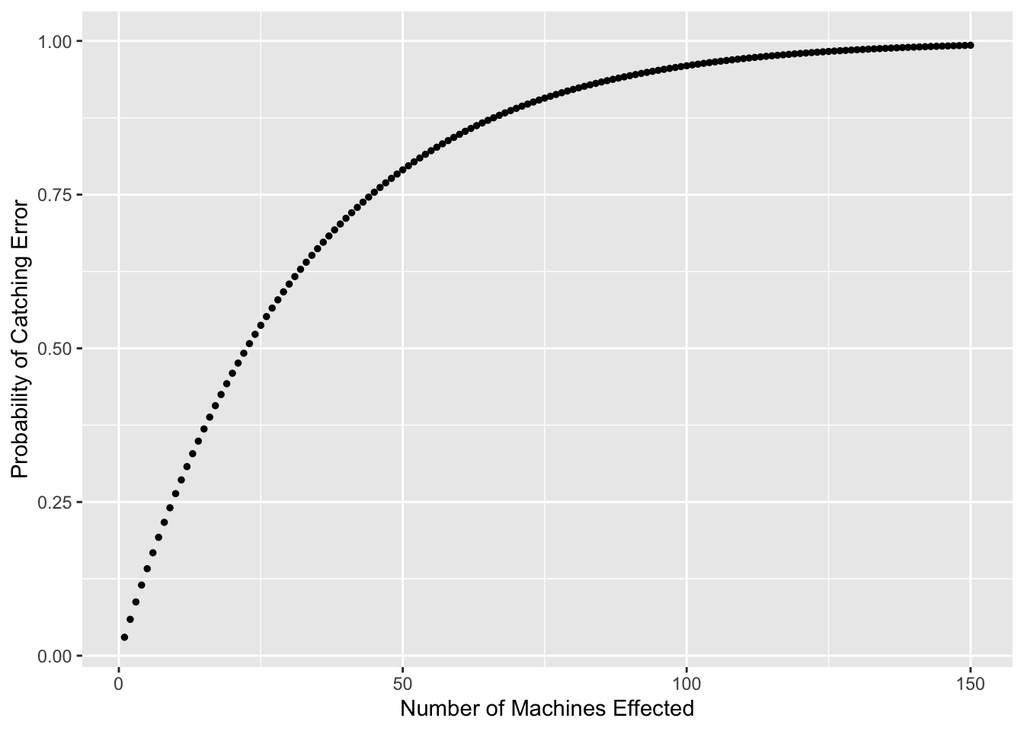

```r
get_catch_probability <- function(bad_machines, total_machines = 1000){
  #compute 3% of total_machines to sample
  sample_size <- round(.03 * total_machines)
  probability <- 1 - choose(total_machines - bad_machines, sample_size)/choose(total_machines, sample_size)
  probability
}

grid <- 1:1000
catch_probs <- get_catch_probability(bad_machines = grid, total_machines = 1000)

catch_frame <- data.frame(grid, catch_probs)
catch_plot <- ggplot(catch_frame, aes(x = grid, y = catch_probs)) +
  geom_point(size = 1) +
  xlim(1,150) +
  ylab("Probability of Catching Error") +
  xlab("Number of Machines Effected")
catch_plot
```

The auditing procedure gives no lower bound on the probability that a wrong outcome will be corrected (unlike a risk limiting audit which does). Since the audit rules are public knowledge, an intelligent hacker could change the results of an election by concentrating discrepancies on as few machines as possible, leading to a very small probability of detection under this audit procedure.

# Unit Test

First we run a very simple unit test of the function by feeding it an election that should definitely be confirmed (the reported and true results are exactly the same), and one that should definitely be flagged as wrong (there are 1% discrepancies on every machine).

```r
test_true_counts <- matrix(c(1000,1500), nrow = 50, ncol = 2, byrow = TRUE)
#give one % of votes for candidate 1 to candidate 2
#spread exactly evenly across machines
#should lead to a full hand count every time
difference <- ceiling(.01 * test_true_counts[,1])
discrepancy_matrix <- matrix(c(-difference, difference), nrow = nrow(test_true_counts), ncol = ncol(test_true_counts))
test_reported_counts <- test_true_counts + discrepancy_matrix
test_machine_types <- c(rep("DRE", 25), rep("OS", 25))

#the above should lead to a full hand count
result_wrong <- audit_results(true_counts = test_true_counts, reported_counts = test_reported_counts, machine_types = test_machine_types)$result

#the below should be confirmed as true and reported counts are exactly the same
result_right <- audit_results(true_counts = test_true_counts, reported_counts = test_true_counts, machine_types = test_machine_types)$result

ifelse(result_wrong == "Proceed to full hand count" & result_right == "Audit done; results confirmed", "Works for both correct and discrepant elections", "Something is wrong.")
```

```
## [1] "Works for both correct and discrepant elections"
```

# Simulations

For our simulations we consider NY precinct level data from the 2016 presidential election. For simplicity we make the election into a two contestant election by only considering Hillary Clinton and Donald Trump as candidates. Since we are not able to acquire machine level data, we will work at the precinct level instead, sampling precincts instead of machines and conducting the audits as though precincts are machines. We compare the error rate of the NY audit to a BRAVO ballot-polling RLA as described in [Lindeman, Stark, and Yates (2012)](https://www.usenix.org/system/files/conference/evtwote12/evtwote12-final27.pdf).

```r
# Load NY 2016 Presidential Election Data
data <- read.csv("ny_precinct_2016_presidential.csv")
# Filter data to only look at Clinton and Trump
data <- data %>%
  filter(candidate == "Hillary Clinton" | candidate == "Donald Trump")
# Within a precinct group by candidate to make sure there are no duplicates
# All we really need is the county, precinct, and vote tally for each of the 2 candidates
data <- data %>%
  group_by(county_fips, precinct, candidate) %>%
  summarise(votes = sum(votes))

# Look at number of precincts and votes tallies by county
county_tally <- data %>%
  group_by(county_fips, candidate) %>%
  summarise(num_votes = sum(votes), num_precincts = length(unique(precinct)))
county_tally
```

| county_fips | candidate | num_votes | num_precincts |
| --- | --- | --- | --- |
| 36001 | Donald Trump | 47808 | 317 |
| 36001 | Hillary Clinton | 83071 | 317 |
| 36003 | Donald Trump | 12525 | 37 |
| 36003 | Hillary Clinton | 4882 | 37 |
| 36005 | Donald Trump | 37797 | 937 |
| 36005 | Hillary Clinton | 353646 | 937 |
| 36007 | Donald Trump | 40943 | 141 |
| 36007 | Hillary Clinton | 39212 | 141 |
| 36009 | Donald Trump | 19692 | 55 |
| 36009 | Hillary Clinton | 9497 | 55 |

[output cut: 114 more lines]

Consider county 36027 (Dutchess County) where Hillary Clinton won by 474 votes. If we flip the votes on just 1 “machine”, say City of Beacon W 1 ED 1, Trump would have been declared the winner in that county. Let’s simulate what happens in this county.

```r
county_36027 <- data %>%
  filter(county_fips == 36027) %>%
  spread(candidate, votes)
true_counts <- as.matrix(county_36027[, 3:4])
# Reported counts are true counts with the first precinct information flipped
reported_counts <- true_counts
reported_counts[1, 1] <- true_counts[1, 2]
reported_counts[1, 2] <- true_counts[1, 1]
# Audit results 1000 times and count the number of times it incorrectly confirms the results
ny_error <- 0
n_sims <- 1000
for(i in 1:n_sims){
  ny_audit <- audit_results(true_counts = true_counts, reported_counts = reported_counts, machine_types = rep(1, nrow(true_counts)))
  if(ny_audit$result == "Audit done; results confirmed"){
    ny_error = ny_error + 1
  }
}
# Proportion of errors in the audit
ny_error/n_sims
```

```
## [1] 0.969
```

As expected, since error is concentrated to one machine, this auditing procedure incorrectly blesses the election outcome about 97% of the time.

```r
# True counts from county 36027
true_counts <- as.matrix(county_36027[, 3:4])
# Reported counts are true counts with the first 15 machines giving 5% of hillary's votes to trump
reported_counts <- true_counts
for(i in 1:15){
  reported_counts[i, 1] <- true_counts[i, 1] + ceiling(0.05 * true_counts[i, 2])
  reported_counts[i, 2] <- true_counts[i, 2] - ceiling(0.05 * true_counts[i, 2])
}
# Check that reported counts now declare Trump winner
colSums(reported_counts)
```

```
##    Donald Trump Hillary Clinton
##           62100           61994
```

```r
ny_error <- 0
n_sims <- 1000
for(i in 1:n_sims){
  ny_audit <- audit_results(true_counts = true_counts, reported_counts = reported_counts, machine_types = rep(1, nrow(true_counts)))
  if(ny_audit$result == "Audit done; results confirmed"){
    ny_error = ny_error + 1
  }
}
# Proportion of errors in the audit
ny_error/n_sims
```

```
## [1] 0.653
```

# Workload simulations: BRAVO versus NY Audit

If the reported outcome is correct an RLA will confirm it. A correctly reported outcome can never be overturned by the audit. Within a single county, the New York audit can also only confirm a correct outcome (across counties it is possible that the NY audit overturns a correctly declared outcome). In this setting we are interested in how quickly the audit can stop, i.e. its efficiency, because this means that we can expect a lower workload and thus a less expensive auditing process on average.

```r
# True counts from county 36027
true_counts <- as.matrix(county_36027[, 3:4])
# Reported counts are equal to true counts
reported_counts <- true_counts
colSums(reported_counts)
```

```
##    Donald Trump Hillary Clinton
##           61810           62284
```

```r
#the margin is very small, we expect a large sample size to confirm the election
n_sims <- 1000
ny_workload <- rep(0, n_sims)
rla_workload <- rep(0, n_sims)
for(i in 1:n_sims){
  ny_audit <- audit_results(true_counts = true_counts, reported_counts = reported_counts, machine_types = rep(1, nrow(true_counts)))
  rla <- bravo_audit(true_counts = true_counts, reported_counts = reported_counts, alpha = .05)
  ny_workload[i] <- ny_audit$workload
  rla_workload[i] <- rla$workload
}
# Proportion of errors in the audit

#average workload
mean(ny_workload)
```

```
## [1] 3929.74
```

```r
mean(rla_workload)
```

```
## [1] 121309.3
```

```r
#upper 95% quantile of workload
quantile(ny_workload, prob = .95)
```

```
##     95%
## 4733.05
```

```r
quantile(rla_workload, prob = .95)
```

```
##    95%
## 124094
```

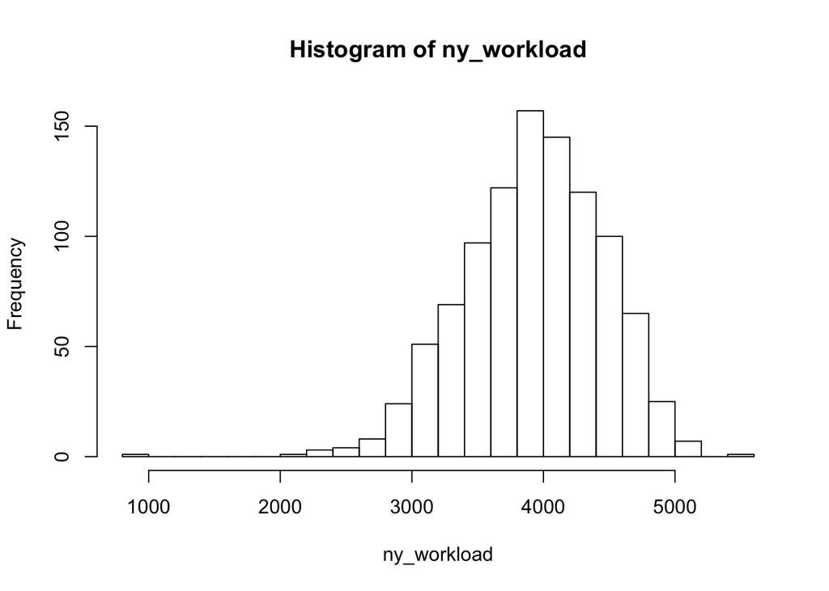

```r
#histograms of workload
hist(ny_workload, breaks = 30)
```

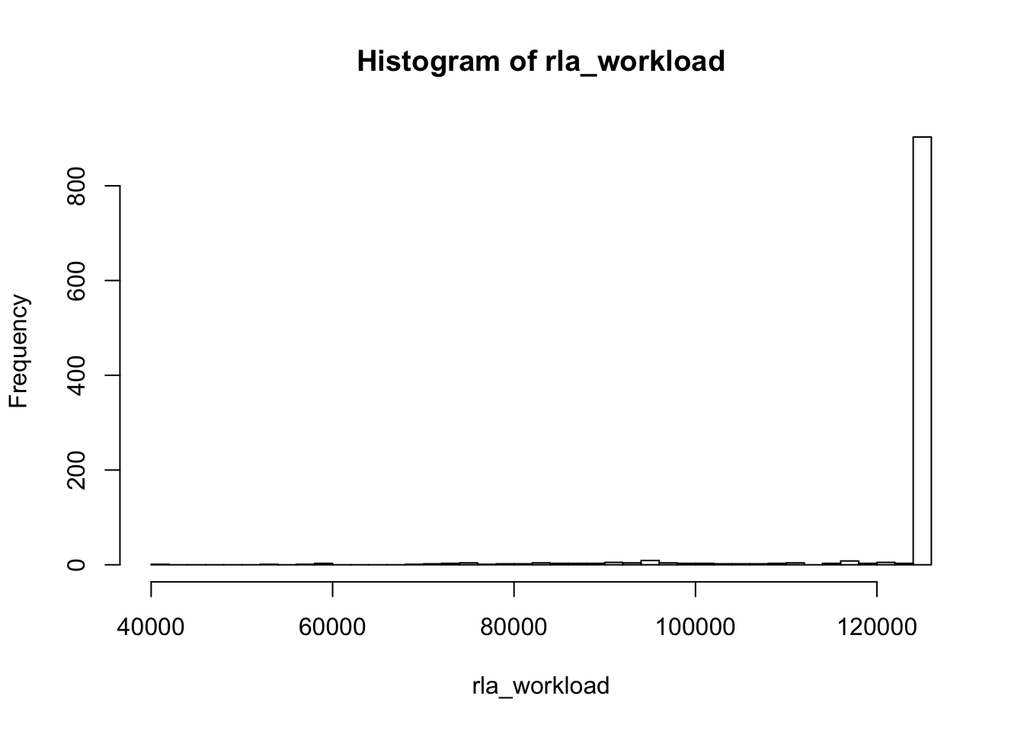

```r
hist(rla_workload, breaks = 30)
```

The margin in this election is only -0.38%. RLAs are far more efficient when the true margin is larger. We also look at county 36011 (Cayuga County), which had a relatively large margin of 12%, with 17384 votes for Trump and 13522 votes for Clinton.

```r
county_36011 <- data %>%
  filter(county_fips == 36011) %>%
  spread(candidate, votes)
# True counts from county 36011
true_counts <- as.matrix(county_36011[, 3:4])
# Reported counts are equal to true counts
reported_counts <- true_counts
colSums(reported_counts)
```

```
##    Donald Trump Hillary Clinton
##           17384           13522
```

```r
#the margin is very small, we expect a large sample size to confirm the election
n_sims <- 1000
ny_workload <- rep(0, n_sims)
rla_workload <- rep(0, n_sims)
for(i in 1:n_sims){
  ny_audit <- audit_results(true_counts = true_counts, reported_counts = reported_counts, machine_types = rep(1, nrow(true_counts)))
  rla <- bravo_audit(true_counts = true_counts, reported_counts = reported_counts, alpha = .05)
  ny_workload[i] <- ny_audit$workload
  rla_workload[i] <- rla$workload
}
# Proportion of errors in the audit

#average workload
mean(ny_workload)
```

```
## [1] 1330.924
```

```r
mean(rla_workload)
```

```
## [1] 399.468
```

```r
#upper 95% quantile of workload
quantile(ny_workload, prob = .95)
```

```
##     95%
## 1948.25
```

```r
quantile(rla_workload, prob = .95)
```

```
##    95%
## 1020.1
```

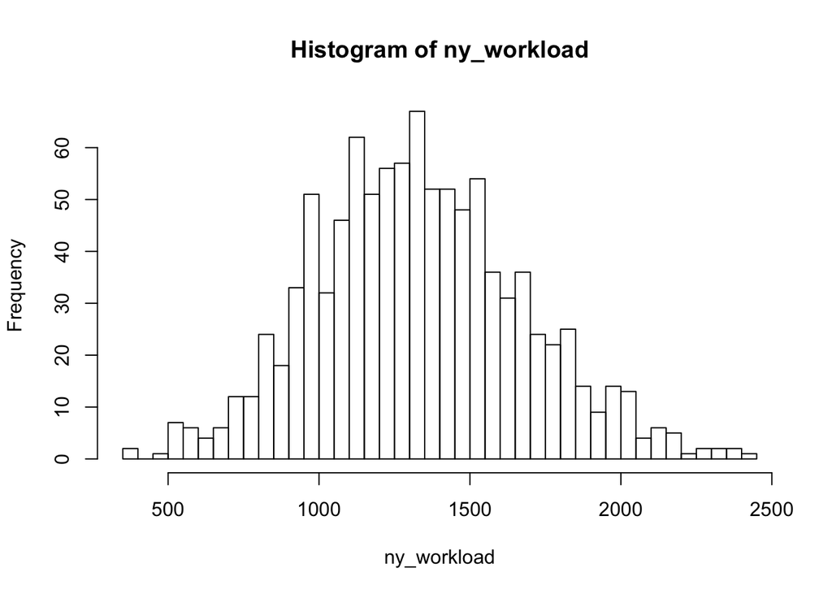

```r
#histograms of workload
hist(ny_workload, breaks = 30)
```

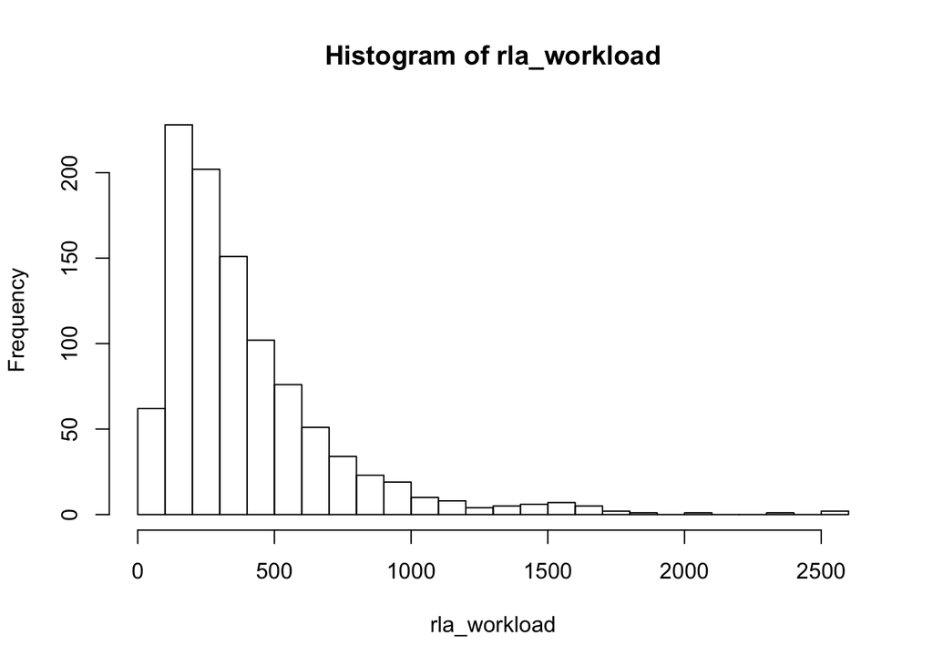

```r
hist(rla_workload, breaks = 30)
```

# Version Info

```r
R.Version()
```

```
## $platform
## [1] "x86_64-apple-darwin15.6.0"
##
## $arch
## [1] "x86_64"
##
## $os
## [1] "darwin15.6.0"
##
## $system
## [1] "x86_64, darwin15.6.0"
##
## $status
## [1] ""
##
## $major
## [1] "3"
##
## $minor
## [1] "6.1"
##
## $year
## [1] "2019"
##
## $month
## [1] "07"
##
## $day
## [1] "05"
##
## $`svn rev`
## [1] "76782"
##
## $language
## [1] "R"
##
## $version.string
## [1] "R version 3.6.1 (2019-07-05)"
##
## $nickname
## [1] "Action of the Toes"
```